# Tutorial 7: Figure 5

Wei-Chun Chou

June, 2020

# Introduction

This tutorial aims to guide you to step-by-step reproduce the results of Figure 5: Histogram of model simulations (right) compared with measured values of PFOS concentrations in maternal plasma (round), cord blood (diamond), and breast milk (square) (left) from different studies using different human populations from all over the world.

# Prerequisites

Before running your model, you should set up your working directory, compile the PBPK model, install all required packages and input needed datasets. The model file and datasets can be found in the additional files.

## Setting up your working directory

The working directory has to be changed to the **PlotCode** folder. You can use two ways to change your working directory as follow:

1. Use RStudio: use the menu to change your working directory under **Session > Set Working Directory > Choose Directory**.
2. Use R function: use the R function `setwd()` to change the path to your working directory.

## Loading required R packages

The list of R packages should be installed prior to the simulation. If you have not installed these packages (listed below), please install these packages to your Rstudio using the R function `require (" ")` and then use `library` open it.

```r
##  Loading requried R packages
library(mrgsolve)    ## R-package for Loading mrgsolve code
library(magrittr)    ## R-package for the pipe, %>% , c
library(dplyr)       ## R-package for transform and summarize
library(tidyverse)   ## R-package for transform and summarize
library(ggplot2)     ## R-package for GGplot
library(FME)         ## R-package for model fitting
library(minpack.lm)  ## R-package for model fitting
library(ggExtra)     ## R-package for function "grid.arrange"
library(EnvStats)    ## R-package for function "rlnormTrunc"
```

## Read mrgsolve-based PBPK Model R file

The pre-pregnant, gestational and lactational PBPK models in humans were written in `HMod.R` file. Before compiling the model, please conduct/call this file using R function `source`.

```r
## Input mrgsolve-based PBPK Model
source (file = "HMod.R") ## input the human model for nonpregnnat, geatation and lactation
```

## Compile mrgsolve-based PBPK Model

Read the code and build these mrgsolve-based PBPK models. You should make sure all models are built correctly.

```r
## Build mrgsolve-based PBPK Model
PreGmod_H <- mcode ("PreGHumanPBPK.code", PreGHumanPBPK.code)
```

```
## Building PreGHumanPBPK_code ... done.
```

```r
Gmod_H    <- mcode ("GHumanPBPK.code", GHumanPBPK.code)
```

```
## Building GHumanPBPK_code ... done.
```

```r
Lmod_H    <- mcode ("LHumanPBPK.code", LHumanPBPK.code)
```

```
## Building LHumanPBPK_code ... done.
```

## Loading datasets

In this step, you need to input the .csv file to the Rstudio. The function `read.csv` can be used to read the csv files into R

```r
HDat <- read.csv(file = "Data_H.csv")
```

## Loading Fit results from rds files to obtain final parameter values

```r
GFit_H <- readRDS(file = "GFit_H.rds")
LFit_H <- readRDS(file = "LFit_H.rds")
```

## Input prediction function (i.e., simulation scenario that needs to use PBPK model to run)

```r
source (file = "Pred_H.R")
```

# Input the human biomonitoring datasets

We input several human biomonitoring studies from the literautre (please refer to the Table 1 in the manuscript).

- Human_MP_G: This dataset represents the maternal plasma during gestaiton.
- Human_CB_G: This dataset represents the cord blood at birth (GA39-40).
- Human_Milk: This dataset represents the maternal milk during lacatation.

```r
## Input human datasets and filter datasets
Human_MP_G <- HDat %>% filter (Cal != 1  & GA >= 39 & Matrix == "MP")
Human_MP_G[is.na(Human_MP_G$SD), "SD"] <- 0
Human_MP_G$no <- seq(1, 9)

Human_CB_G <- HDat %>%  filter (Cal != 1  & GA <= 40 & GA >= 39 & Matrix == "CB")
Human_CB_G[is.na(Human_CB_G$SD), "SD"] <- 0
Human_CB_G$no <- seq(1, 9)

Human_Milk<-HDat %>% filter (Cal != 1  &  GA >= 39 & Matrix == "Milk")
Human_Milk[is.na(Human_Milk$SD), "SD"] <- 0
Human_Milk$no <- c(10, 11, 12)
```

# Define the prediction function from pre-pregnant to gestational exposure

We define serval prediction functions to predict the time-vayring profiles of PFOS in materal palsma, cord blood and milk.

- PBPK_H_G: The prediction function produces the time-varying profiles PFOS in maternal and fetal plasma during gestation.
- PBPK_H_G_pop: The population prediction function produces the population-based time-varying profiles PFOS in maternal and fetal plasma during gestation.
- PBPK_H_L_pop: The population prediction function produces the population-based time-varying profiles PFOS in maternal plasma and milk during lactation.

In the population prediction function, the senstive parameters were chosen by sensitivity analysis and then were assigned as probabilistic distributions (please refer to Tables S9-10).

```r
## Prediction function during gestaiton
PBPK_H_G <- function(pars, DOSE, pred = FALSE) {

Init <- Pred.preG (DOSE) %>% filter (row_number()== n()) %>% select(-c("Plasma", "Liver", "Kidney")) ## Initial concentration from pre-pregnant model

## Get out of log domain
Gpars_H <- lapply(pars, exp)          ## Return a list of exp (parametrs)

## Exposure scenario for gestational exposure
GBW          = 67                     ## Body weight during gestation (use measured data if available);
tinterval    = 24                     ## Time interval;
GTDOSE       = 7*41                   ## Total dosing/Dose times;
GDOSE        = DOSE                   ## Input oral dose
GDOSEoral    = GDOSE*GBW              ## Amount of oral dose

# To create a data set of 1 subject receiving DOSE every 24 hours
Gex.oral <- ev (ID   = 1,             ## One individual
                time = 0,             ## Dosing start time (GA0)
                amt  = GDOSEoral,     ## Amount of dose
                ii   = tinterval,     ## Time interval
                addl = GTDOSE - 1,    ## Additional doseing
                cmt  = "AST",         ## The dosing compartment:
                replicate = FALSE)    ## No replicate

Gtsamp  = tgrid(0, tinterval*(GTDOSE - 1) + 24*1, 24) ## Simulation time from GA0 to GA41 (weeks) + 1 day (run 41 weeks, but obtain data at GA40)

## Simulation of exposure scenario
Gout <-
Gmod_H %>% ## Gestational PBPK model
init(APlas_free = Init$APlas_free, APTC = Init$APTC,
AFil = Init$AFil, AKb = Init$AKb, ARest = Init$ARest,
AL = Init$AL, AM = Init$AM, AF = Init$AF,
A_baso = Init$A_baso, A_apical = Init$A_apical,
Adif = Init$Adif,
Aefflux = Init$Aefflux) %>% ## Input the initial concentrations
param (Gpars_H) %>% ## Update the parameter list with Gpars
update(atol = 1E-5,  maxsteps = 500000) %>%  ## Atol: Absolute tolerance parameter; maxsteps:maximum number of steps
mrgsim_d (data = Gex.oral, tgrid = Gtsamp)

## Extract the "Time", "CPlas", "CL" , "CPlas_P", "CPla" and "Curine" from Gout
Goutdf = cbind.data.frame(
Time = Gout$time/(24*7),   ## Simulation time
CPlas = Gout$Plasma*1000,   ## Unit change from mg/L to ng/mL;
CL = Gout$Liver*1000,    ## PFOS conc. in maternal liver (CL)
CPlas_pup  = Gout$CordB*1000,  ## PFOS conc. in cord blood (CPlas_pup)
CPla     = Gout$Placenta*1000) ## PFOS conc. in placenta (CPla)

if (pred) return (Goutdf)

Init_G <- Gout %>% filter (time == 40*24*7) ## Extract the concentration at GA40
return (Init_G)
}

## Define the population prediction function from pre-pregnant to gestational exposure
PBPK_H_G_pop <- function(pars, pred = FALSE) {

Init <- Pred.preG (DOSE = 7e-7) %>% filter (row_number()== n()) %>% select(-c("Plasma", "Liver", "Kidney"))

## Get out of log domain
Gpars_H <- exp(pars) ## Return a list of exp (parameters for gestational model) from log scale
N <- 1000
## Exposure scenario for gestational exposure
tinterval    = 24                     ## Time interval;
GTDOSE       = 7*40                   ## Total dosing/Dose times;

## Create "N" number of individuals for Monte Carlo analysis.
## Each individal has a combination of parameters
idata <-
        tibble(ID = 1:N) %>%
        mutate(BW        = rnormTrunc (N, min = 27.89, max = 107.5, mean = 67.7, sd = 20.3),
               SA_Htc    = rnormTrunc (N, min = 0.61, max = 1.39, mean = 1, sd = 0.2),
               SA_QC     = rnormTrunc (N, min = 0.61, max = 1.39, mean = 1, sd = 0.2),
               SA_QK_P   = rnormTrunc (N, min = 0.61, max = 1.39, mean = 1, sd = 0.2),
               Free      = rlnormTrunc (N, min = exp(-6.53), max = exp(-5.38), meanlog = -5.96, sdlog = 0.29),
               Free_Fet  = rlnormTrunc (N, min = exp(-6.19), max = exp(-5.04), meanlog = -5.61, sdlog = 0.29),
               KeffluxC  = rlnormTrunc (N, min = exp(-4.82), max = exp(-3.67), meanlog = -4.24, sdlog = 0.29),
               Ktrans1C  = rlnormTrunc (N, min = exp(-0.85), max = exp(0.29), meanlog = -0.28, sdlog = 0.29),
               Ktrans2C  = rlnormTrunc (N, min = exp(-0.51), max = exp(0.65), meanlog = 0.07, sdlog = 0.29),
               QCC       = rnormTrunc  (N, min = 6.76, max = 26.04, mean = 16.4, sd = 4.92),
               Km_apical = 248,
               PPla      = 0.13,
               PL_Fet    = 0.58,
               PRest_Fet = 2.3,
               DOSEoral  = BW*runif(N, min = 1.9e-7, max = 3.7e-6))

# To create the exposure scenario
Gex.oral <- ev (
ID   = 1:N,             ## Number of N individual
time = 0,               ## Dossed strat time
amt  = idata$DOSEoral,  ## Amount of dose
ii   = tinterval,       ## Time interval
addl = GTDOSE - 1,      ## Additional doseing
cmt  = "AST",           ## The dosing compartment: AST Stomach
replicate = FALSE)      ## No replicate

Gtsamp  = tgrid(0, tinterval*(GTDOSE - 1) + 24*7, 1) ## Simulation time from GA0 to GA40 (weeks) + 1 week

## Simulation of exposure scenario
Gout <-
Gmod_H %>% ## Gestational PBPK model
init(APlas_free = Init$APlas_free, APTC = Init$APTC, AFil = Init$AFil,
     AKb = Init$AKb, ARest = Init$ARest,
     AL = Init$AL, AM = Init$AM, AF = Init$AF,
     A_baso = Init$A_baso, A_apical = Init$A_apical, Adif = Init$Adif,
     Aefflux = Init$Aefflux) %>% ## Input the initial concentrations
     idata_set(idata) %>% ## Update the parameter list with Gpars
     update(atol = 1E-3,  maxsteps = 50000) %>%  ## Atol: Absolute tolerance parameter; maxsteps:maximum number of steps
mrgsim (data = Gex.oral, tgrid = Gtsamp)

if (pred) {return (as.data.frame(Gout))}

outdf = Gout %>% filter (time == 24*39*7)

## Extract the concentration
outdf = cbind.data.frame(
ID = outdf$ID,
Time = (outdf$time/(24*7)),
CPlas= outdf$Plasma*1000,
CPlas_pup = outdf$CordB*1000)

return (outdf)

}


## Population prediction function for lactation
PBPK_H_L_pop <- function(Lpars_H) {

Init_G <- PBPK_H_G (GFit_H$par,  1.9e-7) ## Initial concentraiton from gestaitonal model

## Get out of log domain
Lpars_H <- exp(Lpars_H)           ## Return a list of exp (parametrs for gestational model) from log scale
N <- 1000
## Exposure scenario for lactational exposure
#GBW          = 67                     ## Body weight during gestation (use measured data if available); Default value adopted from Garner et al. (2015)
tinterval    = 24                     ## Time interval;
LTDOSE       = 7*30                   ## Total dosing/Dose times; Based on available data

## Repeat oral dose of GDOSE mg/kg/day;
## Amount of oral dose
 idata <-
        tibble(ID = 1:N) %>%
        mutate(
            SA_BW     = rnormTrunc (N, min = 0.61, max = 1.39, mean = 1, sd = 0.2),
            SA_BW_neo = rnormTrunc (N, min = 0.61, max = 1.39, mean = 1, sd = 0.2),
            Free      = rlnormTrunc (N, min = exp(-3.68), max = exp(-2.94), meanlog = -3.32, sdlog = 0.07),
            Free_neo  = rlnormTrunc (N, min = exp(-4.71), max = exp(-3.87), meanlog = -4.29, sdlog = 0.13),
            KeffluxC  = rlnormTrunc (N, min = exp(-2.52), max = exp(-1.36), meanlog = -1.94, sdlog = 0.19),
            KeffluxC_neo = rlnormTrunc (N, min = exp(-2.52), max = exp(-1.36), meanlog = -1.94, sdlog = 0.19),
            PRest     = rlnormTrunc (N, min = exp(-2.02), max = exp(-1.24), meanlog = -1.63, sdlog = 0.13),
            PRest_neo = rlnormTrunc (N, min = exp(-2.02), max = exp(-1.24), meanlog = -1.63, sdlog = 0.13),
            QCC       = rnormTrunc (N, min = 6.76, max = 26.04, mean = 16.4, sd = 3.28),
            QKC       = rnormTrunc (N, min = 0.07, max = 0.28, mean = 0.175, sd = 0.035),
            RAFbaso   = rlnormTrunc (N, min = exp(-0.618), max = exp(-0.532), meanlog = -0.043, sdlog = 0.29),
            VKC       = rnormTrunc (N, min = 0.002, max = 0.01, mean = 0.004, sd = 0.001),
            RAFapi   = 0.525,
            DOSEoral  = 67*runif(N, min = 1.9e-7, max = 3.7e-6))


# To create a data set of 1 subject receiving DOSE every 24 hours
Lex.oral <- ev (ID   = 1:N,             ## One individual
                amt  = idata$DOSEoral,     ## Amount of dose
                ii   = tinterval,     ## Time interval
                addl = LTDOSE - 1,    ## Additional doseing
                cmt  = "AST",         ## The dosing compartment: AST Stomach
                replicate = FALSE)    ## No replicate

Ltsamp       = tgrid(0, tinterval*(LTDOSE - 1) + 24*7, 24) ## Simulation time from PNW0 to PNW30 with dosing of 1 + (LTDOSE - 1) + 1 week (No dosing)

Lout <- Lmod_H %>% # Lactational model
init(#Input the initial concentration
APlas_free =  Init_G$APlas_free, APTC =  Init_G$APTC, AFil =  Init_G$AFil, AKb =  Init_G$AKb, ARest =  Init_G$ARest,
AL =  Init_G$AL, AM =  Init_G$AM, AF =  Init_G$AF, A_baso =  Init_G$A_baso, A_apical = Init_G$A_apical, Adif =  Init_G$Adif,
Aefflux =  Init_G$Aefflux, APlas_free_neo =  Init_G$APlas_Fet_free,
AL_neo =  Init_G$AL_Fet, ARest_neo =  Init_G$ARest_Fet) %>%
idata_set(idata) %>% # Update the parameter list with pars
update(atol = 1E-3, maxsteps = 500000) %>% # Atol: absolute tolerance parameter; hmax: The maximum step size; maxstep: maximum number of steps the solver will take when advancing from one time to the next
mrgsim (data = Lex.oral, tgrid = Ltsamp)


## Extract the concentration
Loutdf = cbind.data.frame(ID         = Lout$ID,
                          Time       = (Lout$time/(24*7)) + 40,
                          CPlas      = Lout$Plasma*1000,
                          CPlas_pup  = Lout$CPneo*1000,
                          CMilk      = Lout$Milk*1000)

Loutdf  <- rbind.data.frame (Loutdf)
return (Loutdf)

}
```

# Simulation and calculation of the range of PFOS (median, min - max) in maternal plasma, milk and cord blood

In this step, we use the population prediction function (defined above) to simulate the time-vayring profiles of PFOS dring gestation and lactation. Then the PFOS level range is estimated.

- H: The output of population prediction function for gestation model.
- H_2: The output of population prediction function for lactational model.
- H_CPlas: The range of PFOS levels in the maternal plasma.
- H_CPlas_pup: The range of PFOSlevels in the cord blood.
- H_CMilk: The range of PFOS levels in the maternal milk.

```r
H   <- PBPK_H_G_pop(GFit_H$par)%>%
       select(ID = ID,
              Time = Time,
              CPlas = CPlas,
              CPlas_pup = CPlas_pup)

H_2 <- PBPK_H_L_pop(LFit_H$par)%>%
       select(ID = ID,
              Time = Time,
              CMilk = CMilk)%>%filter (Time == 42)


## The calculation of the range of maternal plasma concentrations
H_CPlas <- H %>% summarize (
    median = quantile (CPlas, probs = 0.5),
    min = min (CPlas),
    max = max (CPlas))

## The calculation of the range of fetal plasma (cord blood) concentration
H_CPlas_pup <- H %>% summarize (
    median = quantile (CPlas_pup , probs = 0.5),
    min = min (CPlas_pup),
    max = max (CPlas_pup))

## The calculation of the range of maternal milk concentrations
H_CMilk <- H_2 %>% summarize (
    median = quantile (CMilk , probs = 0.5),
    min = min (CMilk ),
    max = max  (CMilk ))
```

# Create figures

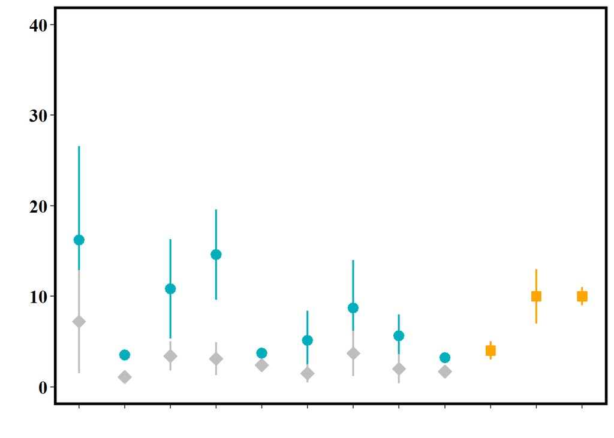

```r
windowsFonts("Times" = windowsFont("Times New Roman"))
p2 <- ggplot() +
geom_pointrange(data = Human_MP_G,
mapping = aes(x = no, y = Conc, ymin = Conc - SD, ymax = Conc + SD),
color ="#00AFBB", fill = "#00AFBB", size = 0.8) +
geom_pointrange(data = Human_CB_G,
mapping = aes(x = no, y = Conc, ymin = Conc - SD, ymax = Conc + SD),
color ="gray", fill = "gray", shape = 23, stroke = 1, size = 0.8) +
geom_pointrange(data = Human_Milk,
mapping = aes(x = no, y = Conc*100, ymin = (Conc - SD)*100, ymax = (Conc + SD)*100),
color ="Orange", fill = "Orange", shape = 22, stroke = 1, size = 0.8) +
scale_x_continuous(breaks=seq(1:13)) +
ylim (0, 40) + labs (x = "", y = "")

# Measured values of PFOS concentrations in maternal plasma (round), cord blood (diamond), and breast milk (square)
p2 <- p2 +
    theme (
        plot.background         = element_rect (fill="White"),
        text                    = element_text (family = "Times"),
        panel.border = element_rect (colour = "black", fill=NA, size=2),
        panel.background        = element_rect (fill="White"),
        panel.grid.major        = element_blank(),
        panel.grid.minor        = element_blank(),
        axis.text.x             = element_blank(),
        axis.text.y             = element_text (size   = 15,
                                  colour = "black", face = "bold"),
        axis.title              = element_text (size   = 18,
                                  colour = "black", face = "bold"),
        legend.position='none')

p2
```

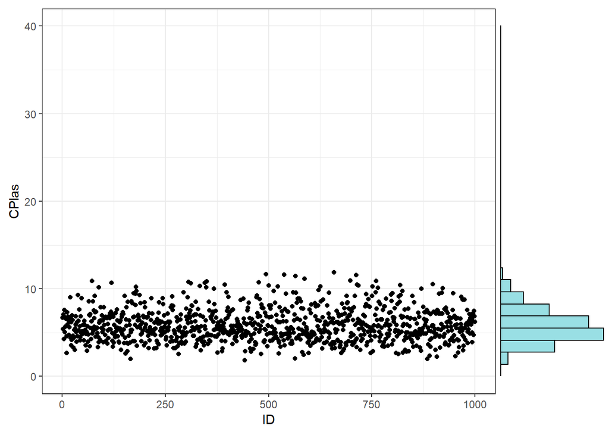

```r
# Histogram of model simulations for maternal plasma
p3 <- ggplot(H, aes(ID, CPlas)) + geom_point() + ylim (0, 40) + theme_bw()
ggMarginal(p3, type = "histogram", margins = "y", size = 4,
           color="black", alpha = 0.4, bins = 30,
           fill = "#00AFBB", position="identity")
```

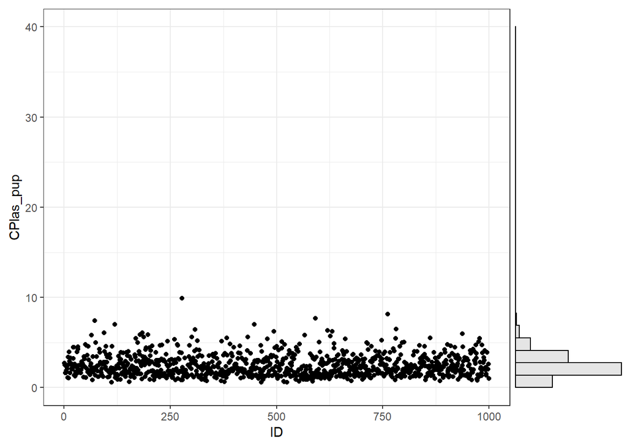

```r
# Histogram of model simulations for cord blood
p4 <- ggplot(H, aes(ID, CPlas_pup)) + geom_point() + ylim (0, 40) + theme_bw()
ggMarginal(p4, type = "histogram", margins = "y", size = 4,
           color = "black", fill="gray", bins = 30, alpha = 0.4)
```

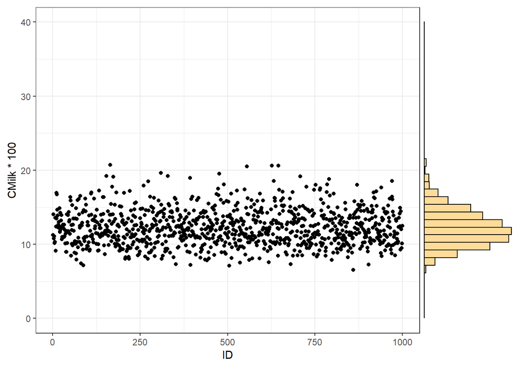

```r
# Histogram of model simulations for maternal milk
p5 <- ggplot(H_2, aes(ID, CMilk*100)) + geom_point() + ylim (0, 40) + theme_bw()
ggMarginal(p5, type = "histogram", margins = "y", size = 4,
           color = "black", fill="Orange", bins = 40, alpha = 0.4)
```

# Save the figure

Save your figures using `ggsave()`. In the `ggsave` function, you should set up the your path to save your figure in the local drive.

```r
# ggsave("Fig.6a1.tiff",scale = 1,
#        plot = p2,
#        path = "C:/Users/weichunc/Desktop",
#        width = 20, height = 10, units = "cm", dpi=320)
#
# ggsave("Fig.6b1.tiff",scale = 1,
#        plot = ggMarginal(
#        p3, type = "histogram", margins = "y", size = 4,
#        color="black", alpha = 0.4, bins = 30,
#        fill = "#00AFBB", position="identity"),
#        path = "C:/Users/weichunc/Desktop",
#        width = 17, height = 12, units = "cm", dpi=320)
#
# ggsave("Fig.6b2.tiff",scale = 1,
#        plot = ggMarginal(
#        p4, type = "histogram", margins = "y", size = 4,
#        color = "black", fill="gray", bins = 30, alpha = 0.4),
#        path = "C:/Users/weichunc/Desktop",
#        width = 17, height = 12, units = "cm", dpi=320)
#
# ggsave("Fig.6b3.tiff",scale = 1,
#        plot = ggMarginal(
#        p5, type = "histogram", margins = "y", size = 4,
#        color = "black", fill="Orange", bins = 40, alpha = 0.4),
#        path = "C:/Users/weichunc/Desktop",
#        width = 17, height = 12, units = "cm", dpi=320)
```